# Happiness Worldwide Reports by Gallup Group

Kristina Z

3/2/2021

# INTRODUCTION

## About

*DATASETS: 2015-2019 KAGGLE*

**Happiness Worldwide Report je kreirala istrazivacko-savetodavna kompanija iz New York-a, SAD - GALLUP WORLD POLL LTD** **Prvi Report je objavljen 2012. godine, u skladu sa Butanskom Rezolucijom koju je prihvatila Generalna Skupstina *UN 2011*. godine kojom je pozvala nacionalne vlade da daju veci znacaj sreci i blagostanju kod merenja socijalnog i ekonomskog razvoja.** **Prvi Izvestaj je formiran u saradnji Kolumbija Univerziteta iz Njujorka sa Kanadskim institutom za napredna istrazivanja, a potom od 2013 godine je baziran na SDSN (Sustainable Development Solutions Network) i Center for Sutainable Develpoment Columbia Univerziteta.** **Bez obzira, osnovni izvor za kreiranje izvestaja cine upitnici koje kreira Gallup Grupa, primenjujuci “Cantril Ladder” sistem.**

**Izuzimajuci sadrzinu upitnika na osnovu kog se procenjuje da li je jedan narod srecniji od drugog, a na osnovu datog dataseta podataka i ovog pristupa proceni srece, mozemo zakljuciti da je narod u zemljama sa boljim skorom srecniji od drugog, koji ima manji score. Na sam score i rangiranje zemalja utice nekoliko faktora i kroz navedeni dataset cemo videti koji faktori najvise uticu na score, odnosno srecu jednog naroda**

# READ THE DATASETS

```r
df <- read.csv("2015.csv")
df1 <- read.csv("2016.csv")
df2 <- read.csv("2017.csv")
df3 <- read.csv("2018.csv")
df4 <-read.csv("2019.csv")
```

# MAIN FEATURES

```r
head(df1)
```

```
##       Country         Region Happiness.Rank Happiness.Score
## 1     Denmark Western Europe              1           7.526
## 2 Switzerland Western Europe              2           7.509
## 3     Iceland Western Europe              3           7.501
## 4      Norway Western Europe              4           7.498
## 5     Finland Western Europe              5           7.413
## 6      Canada  North America              6           7.404
##   Lower.Confidence.Interval Upper.Confidence.Interval
## 1                     7.460                     7.592
## 2                     7.428                     7.590
## 3                     7.333                     7.669
## 4                     7.421                     7.575
## 5                     7.351                     7.475
## 6                     7.335                     7.473
##   Economy..GDP.per.Capita.  Family Health..Life.Expectancy. Freedom
## 1                  1.44178 1.16374                  0.79504 0.57941
## 2                  1.52733 1.14524                  0.86303 0.58557
## 3                  1.42666 1.18326                  0.86733 0.56624
## 4                  1.57744 1.12690                  0.79579 0.59609
## 5                  1.40598 1.13464                  0.81091 0.57104
## 6                  1.44015 1.09610                  0.82760 0.57370
##   Trust..Government.Corruption. Generosity Dystopia.Residual
## 1                       0.44453    0.36171           2.73939
## 2                       0.41203    0.28083           2.69463
## 3                       0.14975    0.47678           2.83137
## 4                       0.35776    0.37895           2.66465
## 5                       0.41004    0.25492           2.82596
## 6                       0.31329    0.44834           2.70485
```

```r
colnames(df1)
```

```
##  [1] "Country"                       "Region"
##  [3] "Happiness.Rank"                "Happiness.Score"
##  [5] "Lower.Confidence.Interval"     "Upper.Confidence.Interval"
##  [7] "Economy..GDP.per.Capita."      "Family"
##  [9] "Health..Life.Expectancy."      "Freedom"
## [11] "Trust..Government.Corruption." "Generosity"
## [13] "Dystopia.Residual"
```

```r
colnames(df2)
```

```
##  [1] "Country"                       "Happiness.Rank"
##  [3] "Happiness.Score"               "Whisker.high"
##  [5] "Whisker.low"                   "Economy..GDP.per.Capita."
##  [7] "Family"                        "Health..Life.Expectancy."
##  [9] "Freedom"                       "Generosity"
## [11] "Trust..Government.Corruption." "Dystopia.Residual"
```

```r
colnames(df3)
```

```
## [1] "Overall.rank"                 "Country.or.region"
## [3] "Score"                        "GDP.per.capita"
## [5] "Social.support"               "Healthy.life.expectancy"
## [7] "Freedom.to.make.life.choices" "Generosity"
## [9] "Perceptions.of.corruption"
```

```r
colnames(df4)
```

```
## [1] "Overall.rank"                 "Country.or.region"
## [3] "Score"                        "GDP.per.capita"
## [5] "Social.support"               "Healthy.life.expectancy"
## [7] "Freedom.to.make.life.choices" "Generosity"
## [9] "Perceptions.of.corruption"
```

```r
colnames(df4)
```

```
## [1] "Overall.rank"                 "Country.or.region"
## [3] "Score"                        "GDP.per.capita"
## [5] "Social.support"               "Healthy.life.expectancy"
## [7] "Freedom.to.make.life.choices" "Generosity"
## [9] "Perceptions.of.corruption"
```

```r
colnames(df3)
```

```
## [1] "Overall.rank"                 "Country.or.region"
## [3] "Score"                        "GDP.per.capita"
## [5] "Social.support"               "Healthy.life.expectancy"
## [7] "Freedom.to.make.life.choices" "Generosity"
## [9] "Perceptions.of.corruption"
```

```r
colnames(df2)
```

```
##  [1] "Country"                       "Happiness.Rank"
##  [3] "Happiness.Score"               "Whisker.high"
##  [5] "Whisker.low"                   "Economy..GDP.per.Capita."
##  [7] "Family"                        "Health..Life.Expectancy."
##  [9] "Freedom"                       "Generosity"
## [11] "Trust..Government.Corruption." "Dystopia.Residual"
```

```r
colnames(df1)
```

```
##  [1] "Country"                       "Region"
##  [3] "Happiness.Rank"                "Happiness.Score"
##  [5] "Lower.Confidence.Interval"     "Upper.Confidence.Interval"
##  [7] "Economy..GDP.per.Capita."      "Family"
##  [9] "Health..Life.Expectancy."      "Freedom"
## [11] "Trust..Government.Corruption." "Generosity"
## [13] "Dystopia.Residual"
```

```r
colnames(df)
```

```
##  [1] "Country"                       "Region"
##  [3] "Happiness.Rank"                "Happiness.Score"
##  [5] "Standard.Error"                "Economy..GDP.per.Capita."
##  [7] "Family"                        "Health..Life.Expectancy."
##  [9] "Freedom"                       "Trust..Government.Corruption."
## [11] "Generosity"                    "Dystopia.Residual"
```

### INSTALACIJA NEOPHODNIH PAKETA

## IMPLEMENTACIJA PAKETA

```r
library('dplyr')
library('tidyverse')
```

```r
library('ggplot2')
```

# EDA

View the structure of data, rename or drop some columns, in order to join them into one, adding column YEAR in each dataset

```r
dim(df)
```

```
## [1] 158  12
```

```r
dim(df1)
```

```
## [1] 157  13
```

```r
dim(df2)
```

```
## [1] 155  12
```

```r
dim(df3)
```

```
## [1] 156   9
```

```r
dim((df4))
```

```
## [1] 156   9
```

```r
colnames(df)
```

```
##  [1] "Country"                       "Region"
##  [3] "Happiness.Rank"                "Happiness.Score"
##  [5] "Standard.Error"                "Economy..GDP.per.Capita."
##  [7] "Family"                        "Health..Life.Expectancy."
##  [9] "Freedom"                       "Trust..Government.Corruption."
## [11] "Generosity"                    "Dystopia.Residual"
```

#### cleaning the data

```r
colnames(df)
```

```
##  [1] "Country"                       "Region"
##  [3] "Happiness.Rank"                "Happiness.Score"
##  [5] "Standard.Error"                "Economy..GDP.per.Capita."
##  [7] "Family"                        "Health..Life.Expectancy."
##  [9] "Freedom"                       "Trust..Government.Corruption."
## [11] "Generosity"                    "Dystopia.Residual"
```

```r
df <- df %>% rename(c("Rank" = "Happiness.Rank" ,
                      "Score" = "Happiness.Score",
                      "GDP" = "Economy..GDP.per.Capita.",
                      "Health" = "Health..Life.Expectancy.",
                      "Corruption" = "Trust..Government.Corruption."))
```

```r
colnames(df)
```

```
##  [1] "Country"           "Region"            "Rank"
##  [4] "Score"             "Standard.Error"    "GDP"
##  [7] "Family"            "Health"            "Freedom"
## [10] "Corruption"        "Generosity"        "Dystopia.Residual"
```

#### erase uneccessary columns

```r
df <- df[, -c(2,5,12)]
```

##### checking columns

```r
colnames(df)
```

```
## [1] "Country"    "Rank"       "Score"      "GDP"        "Family"
## [6] "Health"     "Freedom"    "Corruption" "Generosity"
```

#### change of columns place’s

```r
df<-df[,c(2,1,3,4,5,6,7,9,8)]
```

#### checking code

```r
colnames(df)
```

```
## [1] "Rank"       "Country"    "Score"      "GDP"        "Family"
## [6] "Health"     "Freedom"    "Generosity" "Corruption"
```

#### dataset 2016 cleaning

```r
colnames(df1)
```

```
##  [1] "Country"                       "Region"
##  [3] "Happiness.Rank"                "Happiness.Score"
##  [5] "Lower.Confidence.Interval"     "Upper.Confidence.Interval"
##  [7] "Economy..GDP.per.Capita."      "Family"
##  [9] "Health..Life.Expectancy."      "Freedom"
## [11] "Trust..Government.Corruption." "Generosity"
## [13] "Dystopia.Residual"
```

#### cleaning data

```r
df1 <- df1 %>% rename(c("Rank" = "Happiness.Rank" ,
                        "Score" = "Happiness.Score",
                        "GDP" = "Economy..GDP.per.Capita.",
                        "Health" = "Health..Life.Expectancy.",
                        "Corruption" = "Trust..Government.Corruption.",
                        "Dystopia Residual" = "Dystopia.Residual"))
colnames(df1)
```

```
##  [1] "Country"                   "Region"
##  [3] "Rank"                      "Score"
##  [5] "Lower.Confidence.Interval" "Upper.Confidence.Interval"
##  [7] "GDP"                       "Family"
##  [9] "Health"                    "Freedom"
## [11] "Corruption"                "Generosity"
## [13] "Dystopia Residual"
```

#### drop unneccessary columns

```r
df1 <- df1[, -c(2,5,6,13)]
colnames(df1)
```

```
## [1] "Country"    "Rank"       "Score"      "GDP"        "Family"
## [6] "Health"     "Freedom"    "Corruption" "Generosity"
```

#### raspored kolona

```r
df1<-df1[,c(2,1,3,4,5,6,7,9,8)]
colnames(df1)
```

```
## [1] "Rank"       "Country"    "Score"      "GDP"        "Family"
## [6] "Health"     "Freedom"    "Generosity" "Corruption"
```

### dataset 2017

```r
colnames(df2)
```

```
##  [1] "Country"                       "Happiness.Rank"
##  [3] "Happiness.Score"               "Whisker.high"
##  [5] "Whisker.low"                   "Economy..GDP.per.Capita."
##  [7] "Family"                        "Health..Life.Expectancy."
##  [9] "Freedom"                       "Generosity"
## [11] "Trust..Government.Corruption." "Dystopia.Residual"
```

```r
df2 <- df2 %>% rename(c("Rank" = "Happiness.Rank" ,
                         "Score" = "Happiness.Score",
                         "GDP" = "Economy..GDP.per.Capita.",
                         "Health" = "Health..Life.Expectancy.",
                         "Corruption" = "Trust..Government.Corruption.",
                         "Dystopia Residual" = "Dystopia.Residual"))
colnames(df2)
```

```
##  [1] "Country"           "Rank"              "Score"
##  [4] "Whisker.high"      "Whisker.low"       "GDP"
##  [7] "Family"            "Health"            "Freedom"
## [10] "Generosity"        "Corruption"        "Dystopia Residual"
```

#### drop unnneccessary columns

```r
df2 <- df2[, -c(4,5,12)]
colnames(df2)
```

```
## [1] "Country"    "Rank"       "Score"      "GDP"        "Family"
## [6] "Health"     "Freedom"    "Generosity" "Corruption"
```

#### changing place of columns

```r
df2<-df2[,c(2,1,3,4,5,6,7,8,9)]
colnames(df2)
```

```
## [1] "Rank"       "Country"    "Score"      "GDP"        "Family"
## [6] "Health"     "Freedom"    "Generosity" "Corruption"
```

#### dataset 2018

```r
colnames(df3)
```

```
## [1] "Overall.rank"                 "Country.or.region"
## [3] "Score"                        "GDP.per.capita"
## [5] "Social.support"               "Healthy.life.expectancy"
## [7] "Freedom.to.make.life.choices" "Generosity"
## [9] "Perceptions.of.corruption"
```

```r
colnames(df3)
```

```
## [1] "Overall.rank"                 "Country.or.region"
## [3] "Score"                        "GDP.per.capita"
## [5] "Social.support"               "Healthy.life.expectancy"
## [7] "Freedom.to.make.life.choices" "Generosity"
## [9] "Perceptions.of.corruption"
```

```r
df3 <- df3 %>% rename(c("Rank"   = "Overall.rank",
                        "Country"= "Country.or.region",
                        "Score"  = "Score",
                        "GDP"    = "GDP.per.capita",
                        "Family" = "Social.support",
                        "Health" = "Healthy.life.expectancy",
                        "Freedom"= "Freedom.to.make.life.choices",
                        "Corruption"= "Perceptions.of.corruption"))
colnames(df3)
```

```
## [1] "Rank"       "Country"    "Score"      "GDP"        "Family"
## [6] "Health"     "Freedom"    "Generosity" "Corruption"
```

#### dataset df4

```r
colnames(df4)
```

```
## [1] "Overall.rank"                 "Country.or.region"
## [3] "Score"                        "GDP.per.capita"
## [5] "Social.support"               "Healthy.life.expectancy"
## [7] "Freedom.to.make.life.choices" "Generosity"
## [9] "Perceptions.of.corruption"
```

#### cleaning data

```r
df4 <- df4 %>% rename(c("Rank"   = "Overall.rank",
                        "Country"= "Country.or.region",
                        "Score"  = "Score",
                        "GDP"    = "GDP.per.capita",
                        "Family" = "Social.support",
                        "Health" = "Healthy.life.expectancy",
                        "Freedom"= "Freedom.to.make.life.choices",
                        "Corruption"= "Perceptions.of.corruption"))
colnames(df4)
```

```
## [1] "Rank"       "Country"    "Score"      "GDP"        "Family"
## [6] "Health"     "Freedom"    "Generosity" "Corruption"
```

### adding a year to datsets

```r
df <- df %>% mutate(Year = 2015)
df1 <- df1 %>% mutate(Year = 2016)
df2 <- df2 %>% mutate(Year = 2017)
df3 <- df3 %>% mutate(Year = 2018)
df4 <- df4 %>% mutate(Year =2019)
```

#####checking

```r
head(df)
```

```
##   Rank     Country Score     GDP  Family  Health Freedom Generosity
## 1    1 Switzerland 7.587 1.39651 1.34951 0.94143 0.66557    0.29678
## 2    2     Iceland 7.561 1.30232 1.40223 0.94784 0.62877    0.43630
## 3    3     Denmark 7.527 1.32548 1.36058 0.87464 0.64938    0.34139
## 4    4      Norway 7.522 1.45900 1.33095 0.88521 0.66973    0.34699
## 5    5      Canada 7.427 1.32629 1.32261 0.90563 0.63297    0.45811
## 6    6     Finland 7.406 1.29025 1.31826 0.88911 0.64169    0.23351
##   Corruption Year
## 1    0.41978 2015
## 2    0.14145 2015
## 3    0.48357 2015
## 4    0.36503 2015
## 5    0.32957 2015
## 6    0.41372 2015
```

```r
head(df1)
```

```
##   Rank     Country Score     GDP  Family  Health Freedom Generosity
## 1    1     Denmark 7.526 1.44178 1.16374 0.79504 0.57941    0.36171
## 2    2 Switzerland 7.509 1.52733 1.14524 0.86303 0.58557    0.28083
## 3    3     Iceland 7.501 1.42666 1.18326 0.86733 0.56624    0.47678
## 4    4      Norway 7.498 1.57744 1.12690 0.79579 0.59609    0.37895
## 5    5     Finland 7.413 1.40598 1.13464 0.81091 0.57104    0.25492
## 6    6      Canada 7.404 1.44015 1.09610 0.82760 0.57370    0.44834
##   Corruption Year
## 1    0.44453 2016
## 2    0.41203 2016
## 3    0.14975 2016
## 4    0.35776 2016
## 5    0.41004 2016
## 6    0.31329 2016
```

```r
head(df2)
```

```
##   Rank     Country Score      GDP   Family    Health   Freedom Generosity
## 1    1      Norway 7.537 1.616463 1.533524 0.7966665 0.6354226  0.3620122
## 2    2     Denmark 7.522 1.482383 1.551122 0.7925655 0.6260067  0.3552805
## 3    3     Iceland 7.504 1.480633 1.610574 0.8335521 0.6271626  0.4755402
## 4    4 Switzerland 7.494 1.564980 1.516912 0.8581313 0.6200706  0.2905493
## 5    5     Finland 7.469 1.443572 1.540247 0.8091577 0.6179509  0.2454828
## 6    6 Netherlands 7.377 1.503945 1.428939 0.8106961 0.5853845  0.4704898
##   Corruption Year
## 1  0.3159638 2017
## 2  0.4007701 2017
## 3  0.1535266 2017
## 4  0.3670073 2017
## 5  0.3826115 2017
## 6  0.2826618 2017
```

```r
head(df3)
```

```
##   Rank     Country Score   GDP Family Health Freedom Generosity Corruption
## 1    1     Finland 7.632 1.305  1.592  0.874   0.681      0.202      0.393
## 2    2      Norway 7.594 1.456  1.582  0.861   0.686      0.286      0.340
## 3    3     Denmark 7.555 1.351  1.590  0.868   0.683      0.284      0.408
## 4    4     Iceland 7.495 1.343  1.644  0.914   0.677      0.353      0.138
## 5    5 Switzerland 7.487 1.420  1.549  0.927   0.660      0.256      0.357
## 6    6 Netherlands 7.441 1.361  1.488  0.878   0.638      0.333      0.295
##   Year
## 1 2018
## 2 2018
## 3 2018
## 4 2018
## 5 2018
## 6 2018
```

### MERGE OF DATASETS

```r
df_all<-rbind(df,df1,df2,df3,df4)
head(df_all)
```

```
##   Rank     Country Score     GDP  Family  Health Freedom Generosity
## 1    1 Switzerland 7.587 1.39651 1.34951 0.94143 0.66557    0.29678
## 2    2     Iceland 7.561 1.30232 1.40223 0.94784 0.62877    0.43630
## 3    3     Denmark 7.527 1.32548 1.36058 0.87464 0.64938    0.34139
## 4    4      Norway 7.522 1.45900 1.33095 0.88521 0.66973    0.34699
## 5    5      Canada 7.427 1.32629 1.32261 0.90563 0.63297    0.45811
## 6    6     Finland 7.406 1.29025 1.31826 0.88911 0.64169    0.23351
##   Corruption Year
## 1    0.41978 2015
## 2    0.14145 2015
## 3    0.48357 2015
## 4    0.36503 2015
## 5    0.32957 2015
## 6    0.41372 2015
```

#### checking

```r
tail(df_all)
```

```
##     Rank                  Country Score   GDP Family Health Freedom
## 777  151                    Yemen 3.380 0.287  1.163  0.463   0.143
## 778  152                   Rwanda 3.334 0.359  0.711  0.614   0.555
## 779  153                 Tanzania 3.231 0.476  0.885  0.499   0.417
## 780  154              Afghanistan 3.203 0.350  0.517  0.361   0.000
## 781  155 Central African Republic 3.083 0.026  0.000  0.105   0.225
## 782  156              South Sudan 2.853 0.306  0.575  0.295   0.010
##     Generosity Corruption Year
## 777      0.108      0.077 2019
## 778      0.217      0.411 2019
## 779      0.276      0.147 2019
## 780      0.158      0.025 2019
## 781      0.235      0.035 2019
## 782      0.202      0.091 2019
```

```r
head(df_all)
```

```
##   Rank     Country Score     GDP  Family  Health Freedom Generosity
## 1    1 Switzerland 7.587 1.39651 1.34951 0.94143 0.66557    0.29678
## 2    2     Iceland 7.561 1.30232 1.40223 0.94784 0.62877    0.43630
## 3    3     Denmark 7.527 1.32548 1.36058 0.87464 0.64938    0.34139
## 4    4      Norway 7.522 1.45900 1.33095 0.88521 0.66973    0.34699
## 5    5      Canada 7.427 1.32629 1.32261 0.90563 0.63297    0.45811
## 6    6     Finland 7.406 1.29025 1.31826 0.88911 0.64169    0.23351
##   Corruption Year
## 1    0.41978 2015
## 2    0.14145 2015
## 3    0.48357 2015
## 4    0.36503 2015
## 5    0.32957 2015
## 6    0.41372 2015
```

#### checking NA and NULL values

```r
is.na(df_all)
```

[output not shown]

[output cut: 1551 more lines]

```r
is.na(df_all$Corruption)
```

[output not shown]

[output cut: 57 more lines]

```r
sum(is.na(df_all$Corruption))
```

```
## [1] 0
```

```r
sum(is.na(df_all))
```

```
## [1] 0
```

```r
df_all$Corruption <- as.numeric(df_all$Corruption)
sum(is.na(df_all$Corruption))
```

```
## [1] 1
```

```r
df_all$Corruption[is.na(df_all$Corruption)]<- median(df_all$Corruption)
any(is.na(df_all$Corruption))
```

```
## [1] TRUE
```

```r
sum(is.na(df_all$Corruption))
```

```
## [1] 1
```

```r
df_all$Corruption[is.na(df_all$Corruption)]<- mean(df_all$Corruption)
sum(is.na(df_all$Corruption))
```

```
## [1] 1
```

```r
df_all$Corruption[is.na(df_all$Corruption)] <- mean(df_all$Corruption, na.rm = TRUE)
sum(is.na(df_all$Corruption))
```

```
## [1] 0
```

```r
df_all$Country <- as.numeric(as.factor(df_all$Country))

str(df_all)
```

```
## 'data.frame':    782 obs. of  10 variables:
##  $ Rank      : int  1 2 3 4 5 6 7 8 9 10 ...
##  $ Country   : num  136 59 38 106 25 46 100 135 101 7 ...
##  $ Score     : num  7.59 7.56 7.53 7.52 7.43 ...
##  $ GDP       : num  1.4 1.3 1.33 1.46 1.33 ...
##  $ Family    : num  1.35 1.4 1.36 1.33 1.32 ...
##  $ Health    : num  0.941 0.948 0.875 0.885 0.906 ...
##  $ Freedom   : num  0.666 0.629 0.649 0.67 0.633 ...
##  $ Generosity: num  0.297 0.436 0.341 0.347 0.458 ...
##  $ Corruption: num  0.42 0.141 0.484 0.365 0.33 ...
##  $ Year      : num  2015 2015 2015 2015 2015 ...
```

# CORRELATION BETWEEN VARIABLES

```r
cor <- cor(df_all)
colnames(df_all)
```

```
##  [1] "Rank"       "Country"    "Score"      "GDP"        "Family"
##  [6] "Health"     "Freedom"    "Generosity" "Corruption" "Year"
```

```r
head(df_all)
```

```
##   Rank Country Score     GDP  Family  Health Freedom Generosity Corruption
## 1    1     136 7.587 1.39651 1.34951 0.94143 0.66557    0.29678    0.41978
## 2    2      59 7.561 1.30232 1.40223 0.94784 0.62877    0.43630    0.14145
## 3    3      38 7.527 1.32548 1.36058 0.87464 0.64938    0.34139    0.48357
## 4    4     106 7.522 1.45900 1.33095 0.88521 0.66973    0.34699    0.36503
## 5    5      25 7.427 1.32629 1.32261 0.90563 0.63297    0.45811    0.32957
## 6    6      46 7.406 1.29025 1.31826 0.88911 0.64169    0.23351    0.41372
##   Year
## 1 2015
## 2 2015
## 3 2015
## 4 2015
## 5 2015
## 6 2015
```

```r
summary(df_all)
```

```
##       Rank          Country           Score            GDP
##  Min.   :  1.0   Min.   :  1.00   Min.   :2.693   Min.   :0.0000
##  1st Qu.: 40.0   1st Qu.: 41.00   1st Qu.:4.510   1st Qu.:0.6065
##  Median : 79.0   Median : 81.00   Median :5.322   Median :0.9822
##  Mean   : 78.7   Mean   : 81.52   Mean   :5.379   Mean   :0.9160
##  3rd Qu.:118.0   3rd Qu.:121.75   3rd Qu.:6.189   3rd Qu.:1.2362
##  Max.   :158.0   Max.   :170.00   Max.   :7.769   Max.   :2.0960
##      Family           Health          Freedom         Generosity
##  Min.   :0.0000   Min.   :0.0000   Min.   :0.0000   Min.   :0.0000
##  1st Qu.:0.8694   1st Qu.:0.4402   1st Qu.:0.3098   1st Qu.:0.1300
##  Median :1.1247   Median :0.6473   Median :0.4310   Median :0.2020
##  Mean   :1.0784   Mean   :0.6124   Mean   :0.4111   Mean   :0.2186
##  3rd Qu.:1.3273   3rd Qu.:0.8080   3rd Qu.:0.5310   3rd Qu.:0.2788
##  Max.   :1.6440   Max.   :1.1410   Max.   :0.7240   Max.   :0.8381
##    Corruption           Year
##  Min.   :0.00000   Min.   :2015
##  1st Qu.:0.05425   1st Qu.:2016
##  Median :0.09103   Median :2017
##  Mean   :0.12544   Mean   :2017
##  3rd Qu.:0.15586   3rd Qu.:2018
##  Max.   :0.55191   Max.   :2019
```

# LINEAR REGRESSION, RANDOM FOREST AND DECISION TREE

## LINEAR REGRESSION MODEL

```r
library(rpart)
str(df_all)
```

```
## 'data.frame':    782 obs. of  10 variables:
##  $ Rank      : int  1 2 3 4 5 6 7 8 9 10 ...
##  $ Country   : num  136 59 38 106 25 46 100 135 101 7 ...
##  $ Score     : num  7.59 7.56 7.53 7.52 7.43 ...
##  $ GDP       : num  1.4 1.3 1.33 1.46 1.33 ...
##  $ Family    : num  1.35 1.4 1.36 1.33 1.32 ...
##  $ Health    : num  0.941 0.948 0.875 0.885 0.906 ...
##  $ Freedom   : num  0.666 0.629 0.649 0.67 0.633 ...
##  $ Generosity: num  0.297 0.436 0.341 0.347 0.458 ...
##  $ Corruption: num  0.42 0.141 0.484 0.365 0.33 ...
##  $ Year      : num  2015 2015 2015 2015 2015 ...
```

```r
# import libraries za vizuelizaciju da bi videli korelacije izmedju varijabli

library(ggplot2)
library(ggthemes)
num.cols <- sapply(df_all,is.numeric)
cor.data <- cor(df_all[,num.cols])
print(cor.data)
```

```
##                    Rank      Country        Score          GDP      Family
## Rank        1.000000000 -0.026778475 -0.992066495 -0.794790645 -0.64484151
## Country    -0.026778475  1.000000000  0.018927987  0.009571144  0.09419109
## Score      -0.992066495  0.018927987  1.000000000  0.789283997  0.64879934
## GDP        -0.794790645  0.009571144  0.789283997  1.000000000  0.58596553
## Family     -0.644841509  0.094191092  0.648799345  0.585965534  1.00000000
## Health     -0.743654598 -0.015494024  0.742455742  0.784337571  0.57265026
## Freedom    -0.537942231  0.070766860  0.551258003  0.340510988  0.42036084
## Generosity -0.117713311  0.110742475  0.137577734 -0.014560482 -0.03726161
## Corruption -0.372377049  0.061585567  0.398026688  0.304655391  0.12633312
## Year       -0.007767823  0.014893802  0.007064687  0.019768356  0.36743122
##                 Health     Freedom  Generosity  Corruption         Year
## Rank       -0.74365460 -0.53794223 -0.11771331 -0.37237705 -0.007767823
## Country    -0.01549402  0.07076686  0.11074247  0.06158557  0.014893802
## Score       0.74245574  0.55125800  0.13757773  0.39802669  0.007064687
## GDP         0.78433757  0.34051099 -0.01456048  0.30465539  0.019768356
## Family      0.57265026  0.42036084 -0.03726161  0.12633312  0.367431220
## Health      1.00000000  0.34074513  0.01063811  0.25050338  0.130302255
## Freedom     0.34074513  1.00000000  0.29070551  0.45938964  0.010353162
## Generosity  0.01063811  0.29070551  1.00000000  0.31890511 -0.192587432
## Corruption  0.25050338  0.45938964  0.31890511  1.00000000 -0.122224919
## Year        0.13030226  0.01035316 -0.19258743 -0.12222492  1.000000000
```

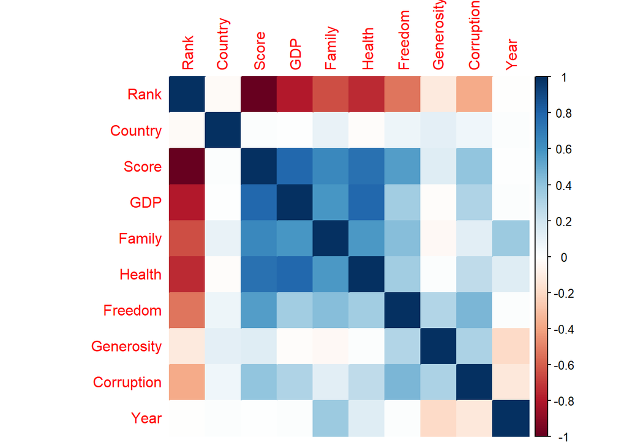

```
##                    Rank      Country        Score          GDP      Family
## Rank        1.000000000 -0.026778475 -0.992066495 -0.794790645 -0.64484151
## Country    -0.026778475  1.000000000  0.018927987  0.009571144  0.09419109
## Score      -0.992066495  0.018927987  1.000000000  0.789283997  0.64879934
## GDP        -0.794790645  0.009571144  0.789283997  1.000000000  0.58596553
## Family     -0.644841509  0.094191092  0.648799345  0.585965534  1.00000000
## Health     -0.743654598 -0.015494024  0.742455742  0.784337571  0.57265026
## Freedom    -0.537942231  0.070766860  0.551258003  0.340510988  0.42036084
## Generosity -0.117713311  0.110742475  0.137577734 -0.014560482 -0.03726161
## Corruption -0.372377049  0.061585567  0.398026688  0.304655391  0.12633312
## Year       -0.007767823  0.014893802  0.007064687  0.019768356  0.36743122
##                 Health     Freedom  Generosity  Corruption         Year
## Rank       -0.74365460 -0.53794223 -0.11771331 -0.37237705 -0.007767823
## Country    -0.01549402  0.07076686  0.11074247  0.06158557  0.014893802
## Score       0.74245574  0.55125800  0.13757773  0.39802669  0.007064687
## GDP         0.78433757  0.34051099 -0.01456048  0.30465539  0.019768356
## Family      0.57265026  0.42036084 -0.03726161  0.12633312  0.367431220
## Health      1.00000000  0.34074513  0.01063811  0.25050338  0.130302255
## Freedom     0.34074513  1.00000000  0.29070551  0.45938964  0.010353162
## Generosity  0.01063811  0.29070551  1.00000000  0.31890511 -0.192587432
## Corruption  0.25050338  0.45938964  0.31890511  1.00000000 -0.122224919
## Year        0.13030226  0.01035316 -0.19258743 -0.12222492  1.000000000
```

```r
#za vizuelizaciju importujemo corrgram i corplot pakete

#install.packages("corrgram")
#install.packages("corrplot")
library(corrgram)
library(corrplot)
print(corrplot(cor.data, method = 'color'))
```

[figure not shown]

```r
corrgram(df_all)
```

```r
help("corrgram")
```

```
## starting httpd help server ...
```

```
##  done
```

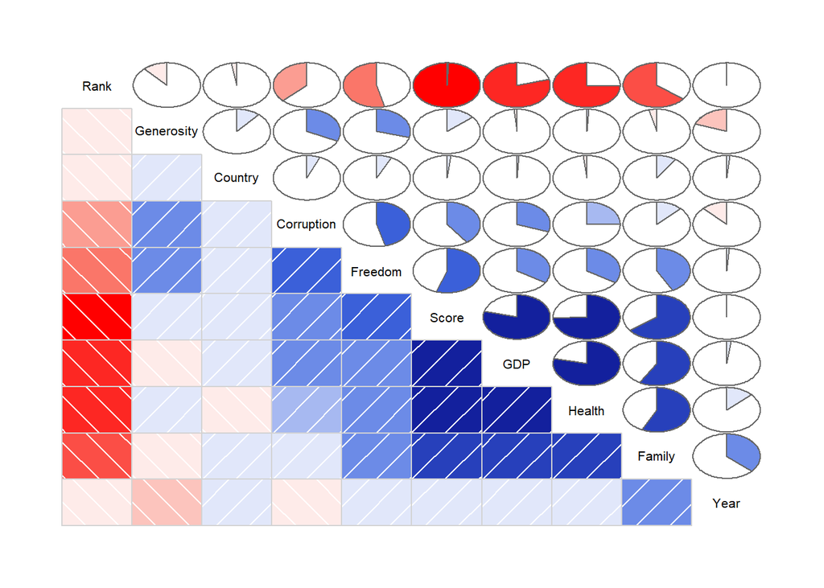

```r
corrgram(df_all, order = TRUE, lower.panel = panel.shade, upper.panel = panel.pie, text.panel = panel.txt)
```

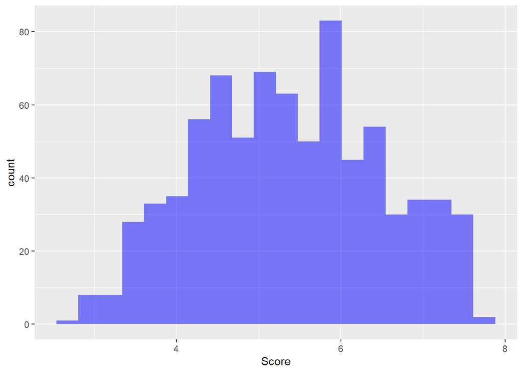

```r
ggplot(df_all,aes(x=Score)) + geom_histogram(bins =
20,alpha=0.5,fill='blue')
```

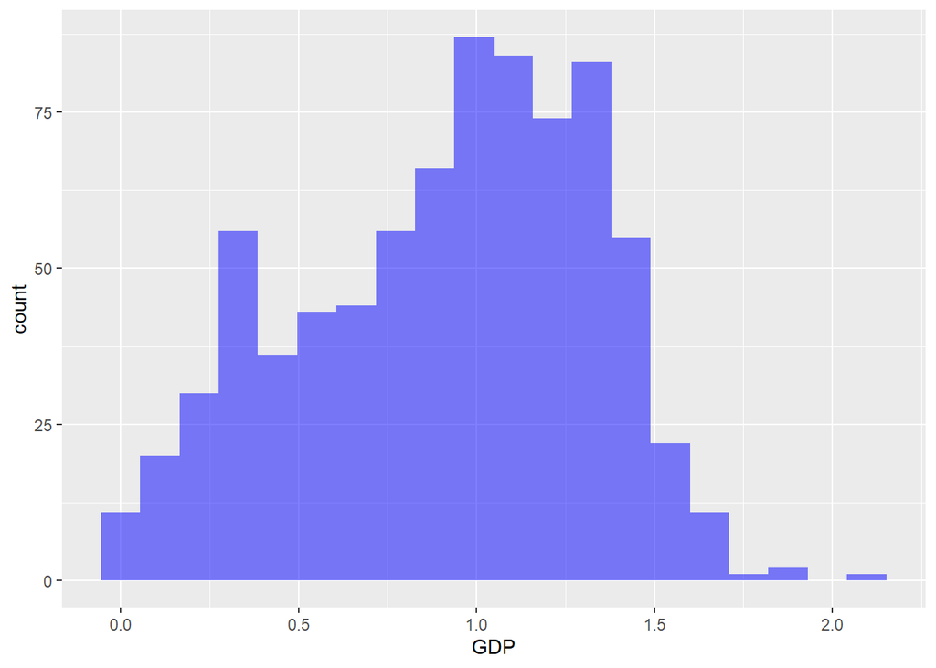

```r
ggplot(df_all,aes(x=GDP)) + geom_histogram(bins = 20,alpha=0.5,fill='blue')
```

```r
#splitting the data into training and testing sets in order to apply ML model

#install.packages('caTools')
library(caTools)
set.seed(101)

#split up sample

sample <- sample.split(df_all$Score,SplitRatio = 0.7)

#70% data na trening, a 30% je test

train <- subset(df_all, sample==TRUE)
test <- subset(df_all, sample==FALSE)

#LINEAR REGGRESSION MODEL U R: #model \<- lm(y\~x1+x2, data)

#TRAIN AND BUILD A MODEL

model <- lm(Score ~ .,train)



#RUN THE MODEL

#INTERPRET THE MODEL
print(summary(model))
```

```
##
## Call:
## lm(formula = Score ~ ., data = train)
##
## Residuals:
##      Min       1Q   Median       3Q      Max
## -0.76097 -0.07621  0.00644  0.08447  0.38988
##
## Coefficients:
##               Estimate Std. Error t value Pr(>|t|)
## (Intercept) 13.0523476  9.5907997   1.361 0.174109
## Rank        -0.0236343  0.0002640 -89.533  < 2e-16 ***
## Country     -0.0003778  0.0001232  -3.067 0.002270 **
## GDP         -0.0129791  0.0270681  -0.479 0.631778
## Family       0.0990609  0.0266736   3.714 0.000226 ***
## Health       0.0578630  0.0404424   1.431 0.153083
## Freedom      0.0070078  0.0516725   0.136 0.892174
## Generosity   0.1702127  0.0543665   3.131 0.001838 **
## Corruption   0.3645928  0.0661915   5.508 5.63e-08 ***
## Year        -0.0029731  0.0047624  -0.624 0.532709
## ---
## Signif. codes:  0 '***' 0.001 '**' 0.01 '*' 0.05 '.' 0.1 ' ' 1
##
## Residual standard error: 0.1355 on 537 degrees of freedom
## Multiple R-squared:  0.986,  Adjusted R-squared:  0.9858
## F-statistic:  4206 on 9 and 537 DF,  p-value: < 2.2e-16
```

```r
res <- residuals(model)

class(res)
```

```
## [1] "numeric"
```

#### PREDICTIONS

```r
Score.predictions <- predict(model, test)

results <-cbind(Score.predictions,test$Score)

colnames(results)<-c('predicted','actual')

results<-as.data.frame(results)

print(head(results))
```

```
##    predicted actual
## 3   7.383540  7.527
## 11  7.023033  7.278
## 12  7.011614  7.226
## 13  7.042817  7.200
## 14  6.925518  7.187
## 17  6.972042  6.946
```

##### taking care of negative values

```r
to_zero<- function(x) {

if (x <0){ return(0) }else{ return(x) } }
```

##### APPLY ZERO FUNCTION

```r
results$predicted<-sapply(results$predicted,to_zero)

min(results)
```

```
## [1] 2.839
```

#### MSE

```r
mse <- mean( (results$actual - results$predicted)^2)
print("MSE")
```

```
## [1] "MSE"
```

```r
print(mse)
```

```
## [1] 0.01794113
```

#### RMSE

```r
print("RMSE")
```

```
## [1] "RMSE"
```

```r
print(mse^0.5)
```

```
## [1] 0.1339445
```

#### SSE SST R2

```r
SSE <- sum( (results$predicted-results$actual)^2)

SST <- sum((mean(df_all$Score)-results$actual)^2)

R2 <- 1- SSE/SST
print('R2')
```

```
## [1] "R2"
```

```r
print(R2)
```

```
## [1] 0.9853487
```

# DECISION TREE

```r
library(rpart)

#splitting the data into training and testing sets in order to deploy ML model

library(caTools)

set.seed(101)

#split up sample

sample_dt <- sample.split(df_all$Score,SplitRatio = 0.7)

#70% data na trening, a 30% je test

train_dt <- subset(df_all, sample==TRUE)

test_dt <- subset(df_all, sample==FALSE)

str(df_all)
```

```
## 'data.frame':    782 obs. of  10 variables:
##  $ Rank      : int  1 2 3 4 5 6 7 8 9 10 ...
##  $ Country   : num  136 59 38 106 25 46 100 135 101 7 ...
##  $ Score     : num  7.59 7.56 7.53 7.52 7.43 ...
##  $ GDP       : num  1.4 1.3 1.33 1.46 1.33 ...
##  $ Family    : num  1.35 1.4 1.36 1.33 1.32 ...
##  $ Health    : num  0.941 0.948 0.875 0.885 0.906 ...
##  $ Freedom   : num  0.666 0.629 0.649 0.67 0.633 ...
##  $ Generosity: num  0.297 0.436 0.341 0.347 0.458 ...
##  $ Corruption: num  0.42 0.141 0.484 0.365 0.33 ...
##  $ Year      : num  2015 2015 2015 2015 2015 ...
```

```r
tree <- rpart(Score~.,method = 'anova',train_dt)

printcp(tree)
```

```
##
## Regression tree:
## rpart(formula = Score ~ ., data = train_dt, method = "anova")
##
## Variables actually used in tree construction:
## [1] Rank
##
## Root node error: 704.97/547 = 1.2888
##
## n= 547
##
##         CP nsplit rel error   xerror      xstd
## 1 0.700187      0  1.000000 1.002733 0.0467621
## 2 0.106013      1  0.299813 0.303927 0.0146135
## 3 0.104389      2  0.193799 0.207480 0.0110498
## 4 0.021313      3  0.089410 0.095021 0.0051746
## 5 0.016959      4  0.068097 0.072495 0.0034493
## 6 0.014637      5  0.051138 0.047115 0.0026845
## 7 0.012093      6  0.036501 0.041964 0.0025725
## 8 0.010000      7  0.024408 0.031498 0.0019460
```

#### INTERPRET THE MODEL

```r
print(summary(tree))
```

```
## Call:
## rpart(formula = Score ~ ., data = train_dt, method = "anova")
##   n= 547
##
##           CP nsplit  rel error     xerror        xstd
## 1 0.70018711      0 1.00000000 1.00273322 0.046762071
## 2 0.10601339      1 0.29981289 0.30392743 0.014613490
## 3 0.10438923      2 0.19379950 0.20747971 0.011049829
## 4 0.02131323      3 0.08941026 0.09502097 0.005174605
## 5 0.01695919      4 0.06809703 0.07249539 0.003449330
## 6 0.01463728      5 0.05113784 0.04711458 0.002684548
## 7 0.01209285      6 0.03650057 0.04196388 0.002572506
## 8 0.01000000      7 0.02440772 0.03149751 0.001945972
##
## Variable importance
##       Rank        GDP     Health     Family    Freedom Corruption
##         31         17         16         14         12          9
## Generosity
##          1
##
## Node number 1: 547 observations,    complexity param=0.7001871
##   mean=5.38675, MSE=1.288801
##   left son=2 (283 obs) right son=3 (264 obs)
##   Primary splits:
##       Rank    < 75.5       to the right, improve=0.7001871, (0 missing)
##       GDP     < 1.02966    to the left,  improve=0.4664119, (0 missing)
##       Health  < 0.5887326  to the left,  improve=0.4502701, (0 missing)
##       Family  < 1.24009    to the left,  improve=0.3425612, (0 missing)
##       Freedom < 0.488895   to the left,  improve=0.2773269, (0 missing)
##   Surrogate splits:
##       GDP        < 1.02966    to the left,  agree=0.821, adj=0.629, (0 split)
##       Health     < 0.5887326  to the left,  agree=0.792, adj=0.568, (0 split)
##       Family     < 1.2035     to the left,  agree=0.784, adj=0.553, (0 split)
##       Freedom    < 0.444093   to the left,  agree=0.731, adj=0.443, (0 split)
##       Corruption < 0.1475     to the left,  agree=0.653, adj=0.280, (0 split)
##
## Node number 2: 283 observations,    complexity param=0.1043892
##   mean=4.469244, MSE=0.3823099
##   left son=4 (131 obs) right son=5 (152 obs)
##   Primary splits:
```

[output cut: 121 more lines]

```
##  1) root 547 704.9743000 5.386750
##    2) Rank>=75.5 283 108.1937000 4.469244
##      4) Rank>=121.5 131  21.2349500 3.919947
##        8) Rank>=143.5 48   3.1960490 3.474604 *
##        9) Rank< 143.5 83   3.0136190 4.177494 *
##      5) Rank< 121.5 152  13.3670100 4.942651
##       10) Rank>=98.5 73   1.7532050 4.671603 *
##       11) Rank< 98.5 79   1.2949040 5.193114 *
##    3) Rank< 75.5 264 103.1667000 6.370288
##      6) Rank>=27.5 171  17.2076700 5.977906
##       12) Rank>=46.5 98   3.2500070 5.749694 *
##       13) Rank< 46.5 73   2.0018670 6.284274 *
##      7) Rank< 27.5 93  11.2223100 7.091763
##       14) Rank>=12.5 47   1.7248820 6.792234 *
##       15) Rank< 12.5 46   0.9722812 7.397804 *
```

```r
res_dt <- residuals(tree)

class(res_dt)
```

```
## [1] "numeric"
```

#### PREDICTIONS

```r
Score.predictions_dt <- predict(tree, test_dt)

results_dt <-cbind(Score.predictions_dt,test_dt$Score)

colnames(results_dt) <-c('predicted','actual')

results_dt<-as.data.frame(results_dt)

print(head(results_dt))
```

```
##    predicted actual
## 3   7.397804  7.527
## 11  7.397804  7.278
## 12  7.397804  7.226
## 13  6.792234  7.200
## 14  6.792234  7.187
## 17  6.792234  6.946
```

#### MSE

```r
mse_dt <- mean( (results_dt$actual - results_dt$predicted)^2)

print("MSE DECISION TREE")
```

```
## [1] "MSE DECISION TREE"
```

```r
print(mse_dt)
```

```
## [1] 0.03711909
```

#### RMSE

```r
print("RMSE")
```

```
## [1] "RMSE"
```

```r
print(mse_dt^0.5)
```

```
## [1] 0.1926631
```

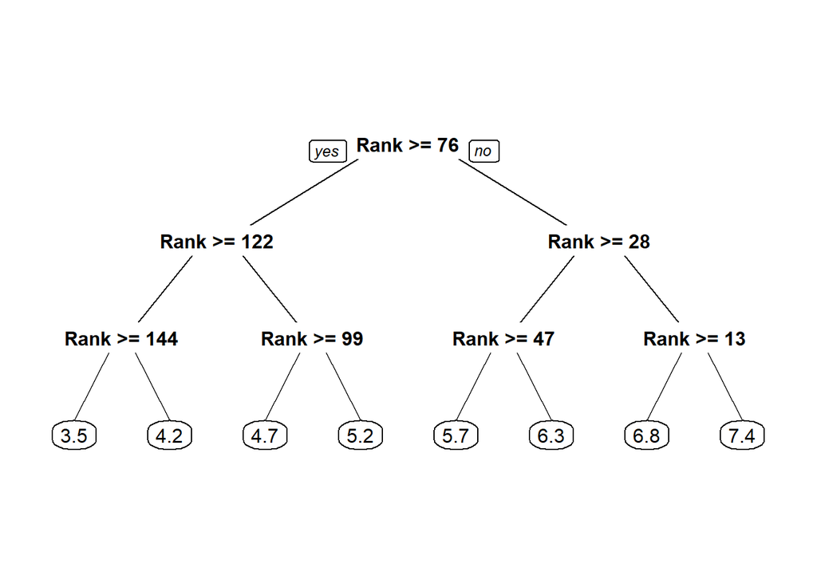

```r
#install.packages('rpart.plot')

library(rpart.plot)
prp(tree)
```

```r
rsq.rpart(tree)
```

```
##
## Regression tree:
## rpart(formula = Score ~ ., data = train_dt, method = "anova")
##
## Variables actually used in tree construction:
## [1] Rank
##
## Root node error: 704.97/547 = 1.2888
##
## n= 547
##
##         CP nsplit rel error   xerror      xstd
## 1 0.700187      0  1.000000 1.002733 0.0467621
## 2 0.106013      1  0.299813 0.303927 0.0146135
## 3 0.104389      2  0.193799 0.207480 0.0110498
## 4 0.021313      3  0.089410 0.095021 0.0051746
## 5 0.016959      4  0.068097 0.072495 0.0034493
## 6 0.014637      5  0.051138 0.047115 0.0026845
## 7 0.012093      6  0.036501 0.041964 0.0025725
## 8 0.010000      7  0.024408 0.031498 0.0019460
```

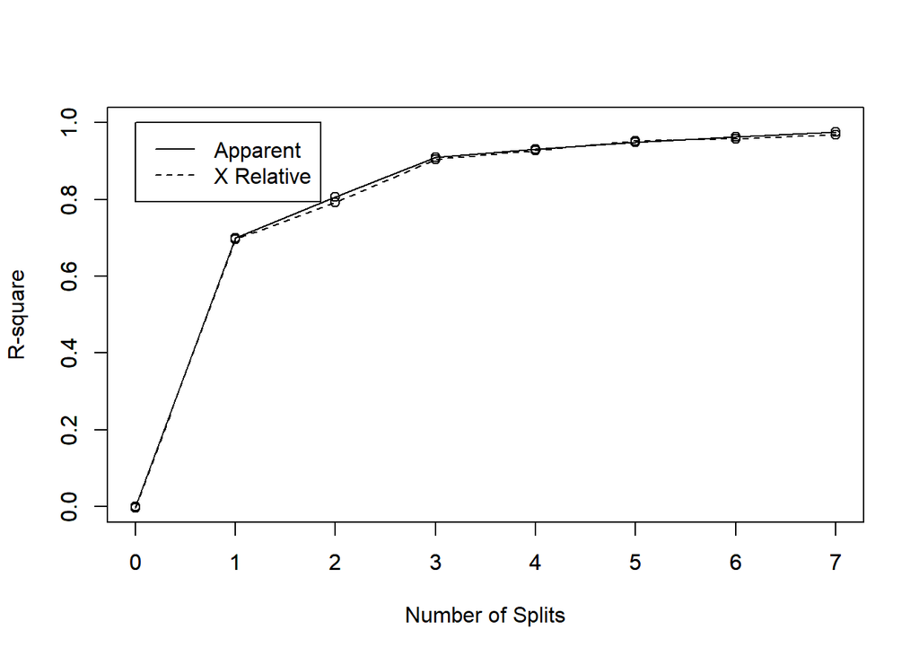

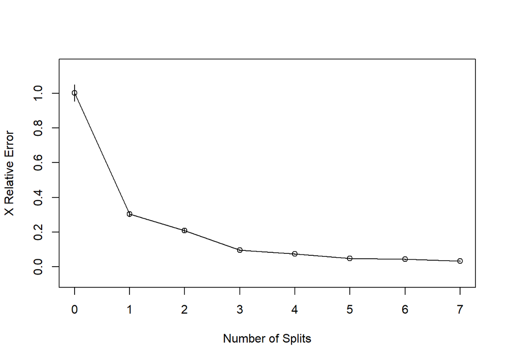

```r
summary(tree)
```

```
## Call:
## rpart(formula = Score ~ ., data = train_dt, method = "anova")
##   n= 547
##
##           CP nsplit  rel error     xerror        xstd
## 1 0.70018711      0 1.00000000 1.00273322 0.046762071
## 2 0.10601339      1 0.29981289 0.30392743 0.014613490
## 3 0.10438923      2 0.19379950 0.20747971 0.011049829
## 4 0.02131323      3 0.08941026 0.09502097 0.005174605
## 5 0.01695919      4 0.06809703 0.07249539 0.003449330
## 6 0.01463728      5 0.05113784 0.04711458 0.002684548
## 7 0.01209285      6 0.03650057 0.04196388 0.002572506
## 8 0.01000000      7 0.02440772 0.03149751 0.001945972
##
## Variable importance
##       Rank        GDP     Health     Family    Freedom Corruption
##         31         17         16         14         12          9
## Generosity
##          1
##
## Node number 1: 547 observations,    complexity param=0.7001871
##   mean=5.38675, MSE=1.288801
##   left son=2 (283 obs) right son=3 (264 obs)
##   Primary splits:
##       Rank    < 75.5       to the right, improve=0.7001871, (0 missing)
##       GDP     < 1.02966    to the left,  improve=0.4664119, (0 missing)
##       Health  < 0.5887326  to the left,  improve=0.4502701, (0 missing)
##       Family  < 1.24009    to the left,  improve=0.3425612, (0 missing)
##       Freedom < 0.488895   to the left,  improve=0.2773269, (0 missing)
##   Surrogate splits:
##       GDP        < 1.02966    to the left,  agree=0.821, adj=0.629, (0 split)
##       Health     < 0.5887326  to the left,  agree=0.792, adj=0.568, (0 split)
##       Family     < 1.2035     to the left,  agree=0.784, adj=0.553, (0 split)
##       Freedom    < 0.444093   to the left,  agree=0.731, adj=0.443, (0 split)
##       Corruption < 0.1475     to the left,  agree=0.653, adj=0.280, (0 split)
##
## Node number 2: 283 observations,    complexity param=0.1043892
##   mean=4.469244, MSE=0.3823099
##   left son=4 (131 obs) right son=5 (152 obs)
##   Primary splits:
```

[output cut: 100 more lines]

```
##
## Node number 11: 79 observations
##   mean=5.193114, MSE=0.01639119
##
## Node number 12: 98 observations
##   mean=5.749694, MSE=0.03316334
##
## Node number 13: 73 observations
##   mean=6.284274, MSE=0.02742283
##
## Node number 14: 47 observations
##   mean=6.792234, MSE=0.03669963
##
## Node number 15: 46 observations
##   mean=7.397804, MSE=0.02113655
```

# RANDOM FOREST MODEL

```r
#install.packages('randomForest')

library(randomForest)
#splitting the data into training and testing sets in order to deploy ML model

library(caTools)

set.seed(101)

#split up sample

sample_rf <- sample.split(df_all$Score,SplitRatio = 0.7)

#70% data na trening, a 30% je test

train_rf <- subset(df_all, sample==TRUE)

test_rf <- subset(df_all, sample==FALSE)

rf.model <- randomForest(Score~.,train_rf)
```

#### INTERPRET THE RESULTS

```r
print(summary(rf.model))
```

```
##                 Length Class  Mode
## call              3    -none- call
## type              1    -none- character
## predicted       547    -none- numeric
## mse             500    -none- numeric
## rsq             500    -none- numeric
## oob.times       547    -none- numeric
## importance        9    -none- numeric
## importanceSD      0    -none- NULL
## localImportance   0    -none- NULL
## proximity         0    -none- NULL
## ntree             1    -none- numeric
## mtry              1    -none- numeric
## forest           11    -none- list
## coefs             0    -none- NULL
## y               547    -none- numeric
## test              0    -none- NULL
## inbag             0    -none- NULL
## terms             3    terms  call
```

```r
res_rf <- residuals(rf.model)

class(res_rf)
```

```
## [1] "NULL"
```

#### PREDICTIONS

```r
Score.predictions_rf <- predict(rf.model, test_rf)

results_rf <-cbind(Score.predictions_rf,test$Score)

colnames(results_rf) <-c('predicted','actual')

results_rf<-as.data.frame(results_rf)

print(head(results_rf))
```

```
##    predicted actual
## 3   7.437880  7.527
## 11  6.836950  7.278
## 12  6.861683  7.226
## 13  7.112572  7.200
## 14  6.571538  7.187
## 17  6.947252  6.946
```

#### MSE

```r
mse_rf <- mean( (results_rf$actual - results_rf$predicted)^2)

print("MSE RANDOM FOREST")
```

```
## [1] "MSE RANDOM FOREST"
```

```r
print(mse_rf)
```

```
## [1] 0.0231838
```

#### RMSE

```r
print("RMSE RANDOM FOREST")
```

```
## [1] "RMSE RANDOM FOREST"
```

```r
print(mse_rf^0.5)
```

```
## [1] 0.1522623
```

```r
print(rf.model)
```

```
##
## Call:
##  randomForest(formula = Score ~ ., data = train_rf)
##                Type of random forest: regression
##                      Number of trees: 500
## No. of variables tried at each split: 3
##
##           Mean of squared residuals: 0.01976854
##                     % Var explained: 98.47
```

```r
rf.model$ntree
```

```
## [1] 500
```

```r
rf.model$mse
```

```
##   [1] 0.14322498 0.14917191 0.09241648 0.08591494 0.07803435 0.08472503
##   [7] 0.08148093 0.08150422 0.07109111 0.06772368 0.06635482 0.06108870
##  [13] 0.05827283 0.05866380 0.05262060 0.05257714 0.04839030 0.04527738
##  [19] 0.04334065 0.04152096 0.04225356 0.04021463 0.03788238 0.03665751
##  [25] 0.03479310 0.03349726 0.03215956 0.03202217 0.03131206 0.02960964
##  [31] 0.02868965 0.02768342 0.02806813 0.02842864 0.02811430 0.02788552
##  [37] 0.02735738 0.02757861 0.02655614 0.02575648 0.02545496 0.02521107
##  [43] 0.02493618 0.02468194 0.02453389 0.02402608 0.02424254 0.02409069
##  [49] 0.02378012 0.02462651 0.02463998 0.02418949 0.02421955 0.02398826
##  [55] 0.02470805 0.02414755 0.02436883 0.02464420 0.02497315 0.02465056
##  [61] 0.02462383 0.02452088 0.02445907 0.02422271 0.02419329 0.02405864
##  [67] 0.02365103 0.02381545 0.02349096 0.02361762 0.02349273 0.02402054
##  [73] 0.02385625 0.02359940 0.02339513 0.02379254 0.02378071 0.02343241
##  [79] 0.02362831 0.02342325 0.02367904 0.02366929 0.02338670 0.02351056
##  [85] 0.02337540 0.02332664 0.02317534 0.02287949 0.02284185 0.02275959
```

[output cut: 69 more lines]

```r
rf.model$rsq
```

```
##   [1] 0.8888696 0.8842553 0.9282927 0.9333373 0.9394520 0.9342606 0.9367777
##   [8] 0.9367597 0.9448394 0.9474522 0.9485143 0.9526004 0.9547852 0.9544819
##  [15] 0.9591709 0.9592046 0.9624533 0.9648686 0.9663713 0.9677833 0.9672148
##  [22] 0.9687969 0.9706065 0.9715569 0.9730035 0.9740090 0.9750469 0.9751535
##  [29] 0.9757045 0.9770254 0.9777393 0.9785200 0.9782215 0.9779418 0.9781857
##  [36] 0.9783632 0.9787730 0.9786013 0.9793947 0.9800152 0.9802491 0.9804384
##  [43] 0.9806517 0.9808489 0.9809638 0.9813578 0.9811899 0.9813077 0.9815487
##  [50] 0.9808919 0.9808815 0.9812310 0.9812077 0.9813872 0.9808287 0.9812636
##  [57] 0.9810919 0.9808782 0.9806230 0.9808733 0.9808940 0.9809739 0.9810218
##  [64] 0.9812052 0.9812281 0.9813325 0.9816488 0.9815212 0.9817730 0.9816747
##  [71] 0.9817716 0.9813621 0.9814896 0.9816889 0.9818474 0.9815390 0.9815482
##  [78] 0.9818184 0.9816664 0.9818256 0.9816271 0.9816346 0.9818539 0.9817578
##  [85] 0.9818627 0.9819005 0.9820179 0.9822475 0.9822767 0.9823405 0.9824951
##  [92] 0.9826672 0.9828031 0.9828065 0.9828074 0.9829210 0.9830382 0.9831698
##  [99] 0.9832819 0.9834015 0.9833693 0.9835710 0.9835087 0.9833970 0.9832475
```

[output cut: 57 more lines]

```r
rf.model$predicted
```

[output not shown]

[output cut: 83 more lines]

[output not shown]

```r
rf.model$type
```

```
## [1] "regression"
```

```r
rf.model$oob.times
```

[output not shown]

[output cut: 18 more lines]

```r
rf.model$proximity
```

```r
rf.model$summary
```

```r
summary(rf.model$train_rf)
```

```
## Length  Class   Mode
##      0   NULL   NULL
```

```r
summary(rf.model$test_rf)
```

```
## Length  Class   Mode
##      0   NULL   NULL
```